# Análisis de Factores

Ana Luisa Masetto Herrea

## Introducción

En este documento se presenta el análisis de factores para la base de datos relacionada con los tipos de cambio desde 1970 hasta 2010 de 80 países.

## Cargar datos

```r
tipo_de_cambio <- readxl::read_xls("est46114_s06_data.xls")
#Convertir datos a serie de tiempo con ts(), solamente se seleccionan 3 países para ilustración
tipo_de_cambio_canada <- ts(tipo_de_cambio$Canada,start = c(1970,01), frequency = 12)
tipo_de_cambio_zambia <- ts(tipo_de_cambio$Zambia,start = c(1970,01), frequency = 12)
tipo_de_cambio_mexico <- ts(tipo_de_cambio$Mexico,start = c(1970,01), frequency = 12)
```

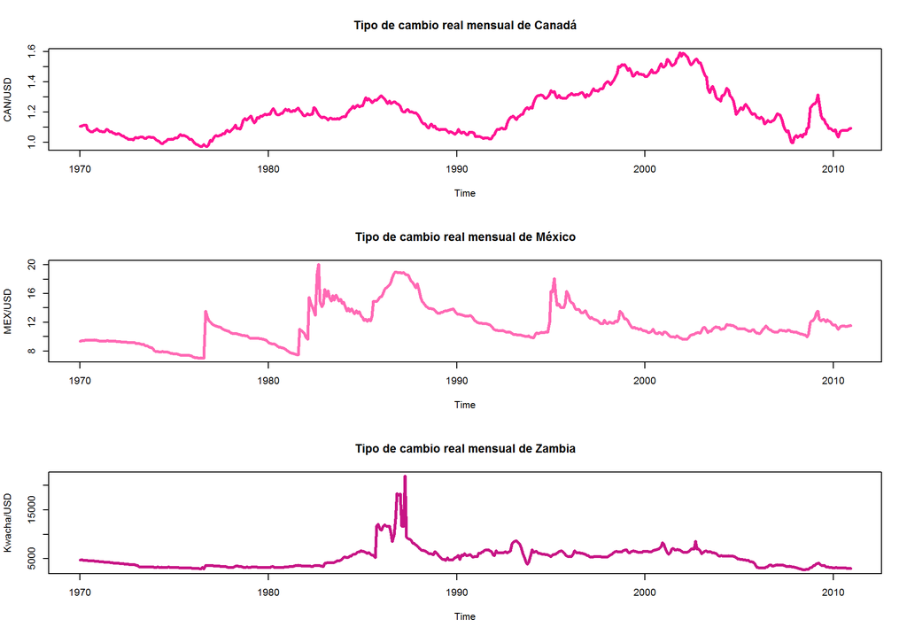

```r
par(mfrow = c(3,1))
plot(tipo_de_cambio_canada, main = "Tipo de cambio real mensual de Canadá", col = "deeppink1", ylab="CAN/USD", lwd=3)
plot(tipo_de_cambio_mexico, main = "Tipo de cambio real mensual de México", col = "hotpink", ylab="MEX/USD", lwd=3)
plot(tipo_de_cambio_zambia, main = "Tipo de cambio real mensual de Zambia", col = "mediumvioletred", ylab="Kwacha/USD", lwd=3)
```

Lo que se puede observar en las gráficas anteriores es el comportamiento del tipo de cambio de los 3 países a lo largo de los 41 años. Es claro que este comportamiento difiere mucho de país en país y de año en año en cada escenario, por lo tanto, no se puede extraer demasiada información de estas gráficas; es por eso que a continuación se ve a hacer un análisis de las medias anuales de dichos paises para notar con mayor facilidad el cambio del tipo de cambio a lo largo de los años.

## Medias por año

```r
#Función para obtener medias y desviaaciones estpandar
tipo_de_cambio_pais_promedio_anual <- function(x,pais){
  fecha <- as.Date(x$Date)
  tipo_de_cambio_mensual <-unname(unlist(x[pais]))

  datos_mensuales <- data_frame(fecha, tipo_de_cambio_mensual)

  datos_anuales <- datos_mensuales %>%
    group_by(year=floor_date(fecha, "year")) %>%
    summarize(media_anual = mean(tipo_de_cambio_mensual),
              desv_anual = sd(tipo_de_cambio_mensual))
  datos_anuales

}
canada_tc_prom_anual <- tipo_de_cambio_pais_promedio_anual(x = tipo_de_cambio,pais = "Canada")
mexico_tc_prom_anual <- tipo_de_cambio_pais_promedio_anual(x = tipo_de_cambio,pais = "Mexico")
zampbia_tc_prom_anual <- tipo_de_cambio_pais_promedio_anual(x = tipo_de_cambio,pais = "Zambia")
```

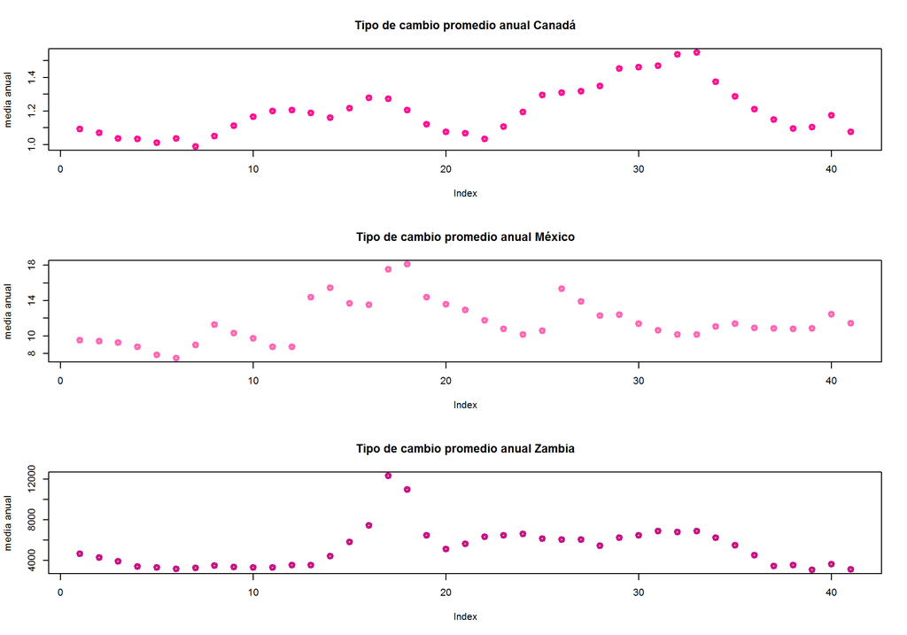

```r
par(mfrow = c(3,1))
plot(canada_tc_prom_anual$media_anual, main="Tipo de cambio promedio anual Canadá", col = "deeppink1", type = "p", lwd=3, ylab="media anual")
plot(mexico_tc_prom_anual$media_anual, main="Tipo de cambio promedio anual México", col = "hotpink", type = "p", lwd=3, ylab="media anual")
plot(zampbia_tc_prom_anual$media_anual, main="Tipo de cambio promedio anual Zambia", col = "mediumvioletred", type = "p", lwd=3, ylab="media anual")
```

Lo que se puede observar en las tres gráficas anteriores es que las medias no son iguales, ni siquiera varian en un rango estrecho a lo largo de los años, es por eso que es necesario transformar los datos acorde a su media y desviación estándar anual.

## Centrar y estandarizar datos

```r
#Función para estandarizar los datos
tipo_de_cambio_pais_estandarizado <- function(x, pais){
    datos_mensuales <- x %>% select(Date,pais) %>% mutate(ano = year(Date)) %>% rename(tipo_de_cambio = pais)
    datos_anuales <- tipo_de_cambio_pais_promedio_anual(x,pais) %>% mutate(ano = year(year))

    datos_estandarizados <- datos_mensuales %>% left_join(datos_anuales, by=c("ano")) %>% mutate(tc_estandarizado = (tipo_de_cambio-media_anual) / desv_anual)

    datos_estandarizados %>% select(Date,ano, tc_estandarizado)
}
```

```r
#Aplicar función anterior para los tres países utilizados para ilustración
canada_tc_estandarizado <- tipo_de_cambio_pais_estandarizado(tipo_de_cambio, pais = "Canada")
zambia_tc_estandarizado <- tipo_de_cambio_pais_estandarizado(tipo_de_cambio, pais = "Zambia")
mexico_tc_estandarizado <- tipo_de_cambio_pais_estandarizado(tipo_de_cambio, pais = "Mexico")
```

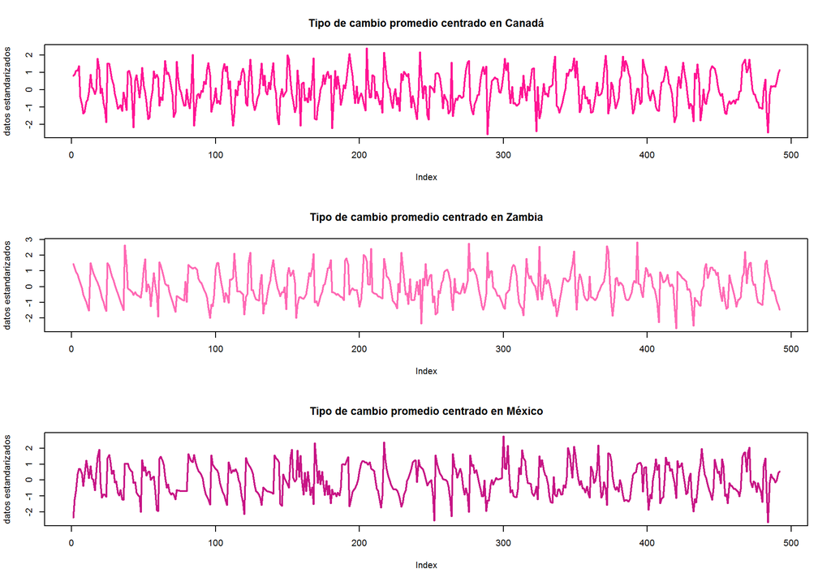

```r
par(mfrow = c(3,1))
plot(canada_tc_estandarizado$tc_estandarizado, main="Tipo de cambio promedio centrado en Canadá", type ="l", col = "deeppink1", lwd=2, ylab="datos estandarizados")
plot(zambia_tc_estandarizado$tc_estandarizado, main="Tipo de cambio promedio centrado en Zambia",  type = "l",col= "hotpink", lwd=2, ylab="datos estandarizados")
plot(mexico_tc_estandarizado$tc_estandarizado, main="Tipo de cambio promedio centrado en México", type = "l", col = "mediumvioletred", lwd=2, ylab="datos estandarizados")
```

## Estandarizar todos datos

```r
#Lista con los 80 países en cuestión
paises_de_interes <- names(tipo_de_cambio)[-1]
head(paises_de_interes,10)
```

```
##  [1] "Canada"        "Mexico"        "Guatemala"     "El Salvador"
##  [5] "Honduras"      "Nicaragua"     "Costa Rica"    "Panama"
##  [9] "Jamaica"       "Dominican Rep"
```

```r
#Aplicar la función de estandarizar los datos a todos los países
lista_paises_estandarizados <- lapply(paises_de_interes, tipo_de_cambio_pais_estandarizado, x = tipo_de_cambio)


#Ponerle nombre a las listas creadas con el nombre anterior
names(lista_paises_estandarizados) <- names(tipo_de_cambio)[-1]

#Juntar las listas
df_tipo_de_cambio_estandarizados <- bind_rows(lista_paises_estandarizados, .id = "column_label") %>%
  spread(column_label,tc_estandarizado)

head(df_tipo_de_cambio_estandarizados)
```

```
## # A tibble: 6 x 82
##   Date                  ano Algeria Argentina Australia Austria Bangladesh
##   <dttm>              <dbl>   <dbl>     <dbl>     <dbl>   <dbl>      <dbl>
## 1 1970-01-01 00:00:00  1970   1.51     -0.432    -1.60  -2.32        1.18
## 2 1970-02-01 00:00:00  1970   1.24     -0.510    -1.44  -0.913       1.05
## 3 1970-03-01 00:00:00  1970   0.967    -0.693    -1.15   0.157       0.922
## 4 1970-04-01 00:00:00  1970   0.719    -0.694    -0.671  1.06        0.906
## 5 1970-05-01 00:00:00  1970   0.434    -0.785    -0.285  1.28        0.654
## 6 1970-06-01 00:00:00  1970   0.171     0.784     0.465 -0.0314      0.481
## # ... with 75 more variables: Benin <dbl>, Brazil <dbl>, Cameroon <dbl>,
## #   Canada <dbl>, Chile <dbl>, `China,PR` <dbl>, Colombia <dbl>,
## #   Congo <dbl>, `Costa Rica` <dbl>, `Cote d'Ivoire` <dbl>, `Czech
## #   Rep` <dbl>, Denmark <dbl>, `Dominican Rep` <dbl>, Ecuador <dbl>,
## #   Egypt <dbl>, `El Salvador` <dbl>, EU12 <dbl>, Finland <dbl>,
## #   France <dbl>, Germany <dbl>, Ghana <dbl>, Greece <dbl>,
## #   Guatemala <dbl>, Honduras <dbl>, `Hong Kong` <dbl>, Hungary <dbl>,
## #   India <dbl>, Indonesia <dbl>, Ireland <dbl>, Israel <dbl>,
## #   Italy <dbl>, Jamaica <dbl>, Japan <dbl>, Jordan <dbl>, Kenya <dbl>,
## #   Korea <dbl>, Kuwait <dbl>, Luxembourg <dbl>, Malaysia <dbl>,
## #   Mexico <dbl>, Morocco <dbl>, Mozambique <dbl>, Netherlands <dbl>, `New
## #   Zealand` <dbl>, Nicaragua <dbl>, Nigeria <dbl>, Norway <dbl>,
## #   Pakistan <dbl>, Panama <dbl>, Paraguay <dbl>, Peru <dbl>,
## #   Philippines <dbl>, Poland <dbl>, Portugal <dbl>, Russia <dbl>, `Saudi
## #   Arabia` <dbl>, Senegal <dbl>, `Sierra Leone` <dbl>, Singapore <dbl>,
## #   `South Africa` <dbl>, Spain <dbl>, `Sri Lanka` <dbl>, Sweden <dbl>,
## #   Switzerland <dbl>, Syria <dbl>, Taiwan <dbl>, Tanzania <dbl>,
## #   Thailand <dbl>, `Trin/Tobago` <dbl>, Tunisia <dbl>, Turkey <dbl>,
## #   U.K. <dbl>, Uruguay <dbl>, Venezuela <dbl>, Zambia <dbl>
```

```r
#Remover columna con año y fecha
matriz_de_diseno <- df_tipo_de_cambio_estandarizados  %>% select(-Date, -ano)
matriz_de_diseno
```

```
## # A tibble: 492 x 80
##    Algeria Argentina Australia Austria Bangladesh   Benin Brazil Cameroon
##      <dbl>     <dbl>     <dbl>   <dbl>      <dbl>   <dbl>  <dbl>    <dbl>
##  1   1.51     -0.432    -1.60  -2.32       1.18   -1.52    0.836    0.828
##  2   1.24     -0.510    -1.44  -0.913      1.05   -1.27    0.915   -0.438
##  3   0.967    -0.693    -1.15   0.157      0.922  -0.904   0.266   -0.574
##  4   0.719    -0.694    -0.671  1.06       0.906  -0.624   1.16    -0.642
##  5   0.434    -0.785    -0.285  1.28       0.654  -0.455   0.970   -0.671
##  6   0.171     0.784     0.465 -0.0314     0.481  -0.0917  0.532   -1.23
##  7  -0.129     1.58      1.02  -1.00       0.0629  0.109   0.347   -0.104
##  8  -0.464     1.36      1.02  -0.179     -0.589   0.261  -0.755   -0.844
##  9  -0.717     0.979     1.12   0.354     -0.768   0.622  -1.44    -0.381
## 10  -0.970     0.280     0.891  0.458     -0.957   1.03   -1.79     0.744
## # ... with 482 more rows, and 72 more variables: Canada <dbl>,
## #   Chile <dbl>, `China,PR` <dbl>, Colombia <dbl>, Congo <dbl>, `Costa
## #   Rica` <dbl>, `Cote d'Ivoire` <dbl>, `Czech Rep` <dbl>, Denmark <dbl>,
## #   `Dominican Rep` <dbl>, Ecuador <dbl>, Egypt <dbl>, `El
## #   Salvador` <dbl>, EU12 <dbl>, Finland <dbl>, France <dbl>,
## #   Germany <dbl>, Ghana <dbl>, Greece <dbl>, Guatemala <dbl>,
## #   Honduras <dbl>, `Hong Kong` <dbl>, Hungary <dbl>, India <dbl>,
## #   Indonesia <dbl>, Ireland <dbl>, Israel <dbl>, Italy <dbl>,
## #   Jamaica <dbl>, Japan <dbl>, Jordan <dbl>, Kenya <dbl>, Korea <dbl>,
## #   Kuwait <dbl>, Luxembourg <dbl>, Malaysia <dbl>, Mexico <dbl>,
## #   Morocco <dbl>, Mozambique <dbl>, Netherlands <dbl>, `New
## #   Zealand` <dbl>, Nicaragua <dbl>, Nigeria <dbl>, Norway <dbl>,
## #   Pakistan <dbl>, Panama <dbl>, Paraguay <dbl>, Peru <dbl>,
## #   Philippines <dbl>, Poland <dbl>, Portugal <dbl>, Russia <dbl>, `Saudi
## #   Arabia` <dbl>, Senegal <dbl>, `Sierra Leone` <dbl>, Singapore <dbl>,
## #   `South Africa` <dbl>, Spain <dbl>, `Sri Lanka` <dbl>, Sweden <dbl>,
## #   Switzerland <dbl>, Syria <dbl>, Taiwan <dbl>, Tanzania <dbl>,
## #   Thailand <dbl>, `Trin/Tobago` <dbl>, Tunisia <dbl>, Turkey <dbl>,
## #   U.K. <dbl>, Uruguay <dbl>, Venezuela <dbl>, Zambia <dbl>
```

## Correr modelo

En esta sección se va a correr el modelo de análisis de factores con la librería de MCMCpack. El primer chunk de esta sección se encarga de hacer las simulaciones y el siguiente da un resumen de los valores obtenidos de las simulaciones, lambdas y desviaciones estándar.

```r
library(MCMCpack)
n <-  nrow(matriz_de_diseno) # n-observaciones
p <- ncol(matriz_de_diseno) # p-dimensiones
k <- 1 # k-factores

data.sim <- matriz_de_diseno

M.sim <- 1000 # simulaciones
M.burn <- 500  # simulaciones para el périodo de calentamiento

# MCMCfactanal: Markov Chain Monte Carlo for Normal Theory Factor Analysis Model
posterior.data.sim <- MCMCfactanal(~.,            # Formula que contiene las variables

                          factors=k,

                          verbose=0, store.scores=FALSE,
                          a0=1,                    # Controla la forma de la Prior Gamma Inversa (alfa)
                          b0=0.15,                 # Controla la forma de la Prior Gamma Inversa (beta)
                          data=data.sim,           # El nombre de un dataframe
                          burnin=M.burn,
                          mcmc=M.sim,
                          thin=20)
```

```r
summary<-summary(posterior.data.sim)[[1]]
head(summary)
```

```
##                          Mean         SD    Naive SE Time-series SE
## LambdaAlgeria_1    -0.3917352 0.07450491 0.010536586    0.010536586
## LambdaArgentina_1  -0.2451315 0.07747092 0.010956043    0.004254798
## LambdaAustralia_1  -0.5620976 0.07097667 0.010037616    0.010037616
## LambdaAustria_1    -1.2162422 0.05718256 0.008086836    0.034507921
## LambdaBangladesh_1 -0.4327046 0.06630728 0.009377266    0.009377266
## LambdaBenin_1      -1.0804383 0.05174515 0.007317869    0.022063639
```

```r
tail(summary)
```

```
##                   Mean          SD    Naive SE Time-series SE
## PsiTunisia   0.1039798 0.007963869 0.001126261    0.001126261
## PsiTurkey    0.8125452 0.058620697 0.008290218    0.008290218
## PsiU.K.      0.4566828 0.031870756 0.004507206    0.004507206
## PsiUruguay   0.9711331 0.080821024 0.011429819    0.014031214
## PsiVenezuela 1.0094428 0.079553260 0.011250530    0.011250530
## PsiZambia    1.0042665 0.085034414 0.012025682    0.012025682
```

Ahora, hay que guardar las simulaciones en un objeto, simulaciones respectivas para cada lambda y para cada psi:

```r
df_simulaciones <- as_data_frame(posterior.data.sim)
head(df_simulaciones)
```

```
## # A tibble: 6 x 160
##   LambdaAlgeria_1 LambdaArgentina~ LambdaAustralia~ LambdaAustria_1
##             <dbl>            <dbl>            <dbl>           <dbl>
## 1          -0.403          -0.166            -0.489           -1.10
## 2          -0.363          -0.275            -0.652           -1.14
## 3          -0.287          -0.375            -0.563           -1.13
## 4          -0.359          -0.0738           -0.559           -1.14
## 5          -0.348          -0.225            -0.542           -1.12
## 6          -0.416          -0.336            -0.443           -1.15
## # ... with 156 more variables: LambdaBangladesh_1 <dbl>,
## #   LambdaBenin_1 <dbl>, LambdaBrazil_1 <dbl>, LambdaCameroon_1 <dbl>,
## #   LambdaCanada_1 <dbl>, LambdaChile_1 <dbl>,
## #   `Lambda\`China,PR\`_1` <dbl>, LambdaColombia_1 <dbl>,
## #   LambdaCongo_1 <dbl>, `Lambda\`Costa Rica\`_1` <dbl>, `Lambda\`Cote
## #   d'Ivoire\`_1` <dbl>, `Lambda\`Czech Rep\`_1` <dbl>,
## #   LambdaDenmark_1 <dbl>, `Lambda\`Dominican Rep\`_1` <dbl>,
## #   LambdaEcuador_1 <dbl>, LambdaEgypt_1 <dbl>, `Lambda\`El
## #   Salvador\`_1` <dbl>, LambdaEU12_1 <dbl>, LambdaFinland_1 <dbl>,
## #   LambdaFrance_1 <dbl>, LambdaGermany_1 <dbl>, LambdaGhana_1 <dbl>,
## #   LambdaGreece_1 <dbl>, LambdaGuatemala_1 <dbl>, LambdaHonduras_1 <dbl>,
## #   `Lambda\`Hong Kong\`_1` <dbl>, LambdaHungary_1 <dbl>,
## #   LambdaIndia_1 <dbl>, LambdaIndonesia_1 <dbl>, LambdaIreland_1 <dbl>,
## #   LambdaIsrael_1 <dbl>, LambdaItaly_1 <dbl>, LambdaJamaica_1 <dbl>,
## #   LambdaJapan_1 <dbl>, LambdaJordan_1 <dbl>, LambdaKenya_1 <dbl>,
## #   LambdaKorea_1 <dbl>, LambdaKuwait_1 <dbl>, LambdaLuxembourg_1 <dbl>,
## #   LambdaMalaysia_1 <dbl>, LambdaMexico_1 <dbl>, LambdaMorocco_1 <dbl>,
## #   LambdaMozambique_1 <dbl>, LambdaNetherlands_1 <dbl>, `Lambda\`New
## #   Zealand\`_1` <dbl>, LambdaNicaragua_1 <dbl>, LambdaNigeria_1 <dbl>,
## #   LambdaNorway_1 <dbl>, LambdaPakistan_1 <dbl>, LambdaPanama_1 <dbl>,
## #   LambdaParaguay_1 <dbl>, LambdaPeru_1 <dbl>, LambdaPhilippines_1 <dbl>,
## #   LambdaPoland_1 <dbl>, LambdaPortugal_1 <dbl>, LambdaRussia_1 <dbl>,
## #   `Lambda\`Saudi Arabia\`_1` <dbl>, LambdaSenegal_1 <dbl>,
## #   `Lambda\`Sierra Leone\`_1` <dbl>, LambdaSingapore_1 <dbl>,
## #   `Lambda\`South Africa\`_1` <dbl>, LambdaSpain_1 <dbl>, `Lambda\`Sri
## #   Lanka\`_1` <dbl>, LambdaSweden_1 <dbl>, LambdaSwitzerland_1 <dbl>,
## #   LambdaSyria_1 <dbl>, LambdaTaiwan_1 <dbl>, LambdaTanzania_1 <dbl>,
## #   LambdaThailand_1 <dbl>, `Lambda\`Trin/Tobago\`_1` <dbl>,
## #   LambdaTunisia_1 <dbl>, LambdaTurkey_1 <dbl>, LambdaU.K._1 <dbl>,
## #   LambdaUruguay_1 <dbl>, LambdaVenezuela_1 <dbl>, LambdaZambia_1 <dbl>,
## #   PsiAlgeria <dbl>, PsiArgentina <dbl>, PsiAustralia <dbl>,
## #   PsiAustria <dbl>, PsiBangladesh <dbl>, PsiBenin <dbl>,
## #   PsiBrazil <dbl>, PsiCameroon <dbl>, PsiCanada <dbl>, PsiChile <dbl>,
## #   `Psi\`China,PR\`` <dbl>, PsiColombia <dbl>, PsiCongo <dbl>,
## #   `Psi\`Costa Rica\`` <dbl>, `Psi\`Cote d'Ivoire\`` <dbl>, `Psi\`Czech
## #   Rep\`` <dbl>, PsiDenmark <dbl>, `Psi\`Dominican Rep\`` <dbl>,
## #   PsiEcuador <dbl>, PsiEgypt <dbl>, `Psi\`El Salvador\`` <dbl>,
## #   PsiEU12 <dbl>, PsiFinland <dbl>, PsiFrance <dbl>, ...
```

## Análisis de resultados de la simulación

Los resultados que salieron de la simulación deben de ser acomodados de tal forma que facilite su manejo, es por eso que en la siguiente parte, se hace un nuevo data frame con las lambdas y psi correspondientes a cada país.

```r
#Filtrar lambdas y sigmas
lambdas <- dplyr::select(df_simulaciones, starts_with("Lamb")) %>%
  summarise_all("mean")  %>%
  gather("pais","lambda", 1:80)

sigma <- dplyr::select(df_simulaciones, starts_with("Psi")) %>%
  summarise_all("mean")  %>%
  gather("pais","psi", 1:80)

#Combinar ambos objetos en u data frame
resultados_promedio <- cbind(lambdas,sigma)

#Asignar nombres a columas del dataframe anterior
names(resultados_promedio) <- c("pais_lambda", "lambda", "pais_sigma", "sigma")

#Remover columnas innecesarias
resultados_promedio <- resultados_promedio %>% dplyr::select(-pais_lambda,-pais_sigma)

#Crear una nueva columna con el nombre de los paises
pais <- names(data.sim)

#Combinar la columna con los nombres de los países y el dataframe con lambdas y sigmas
resultados_promedio <- cbind(pais, resultados_promedio)

head(resultados_promedio)
```

```
##         pais     lambda     sigma
## 1    Algeria -0.3917352 0.8993460
## 2  Argentina -0.2451315 0.9694754
## 3  Australia -0.5620976 0.7898048
## 4    Austria -1.2162422 0.0249438
## 5 Bangladesh -0.4327046 0.8842692
## 6      Benin -1.0804383 0.2237412
```

Como parte del análisis de factores es necesario calcular la varianza muestras de la siguiente manera:

```r
resultados_final<-resultados_promedio %>% mutate("varianza_marginal" = (lambda * lambda) + sigma)
head(resultados_final)
```

```
##         pais     lambda     sigma varianza_marginal
## 1    Algeria -0.3917352 0.8993460          1.052802
## 2  Argentina -0.2451315 0.9694754          1.029565
## 3  Australia -0.5620976 0.7898048          1.105759
## 4    Austria -1.2162422 0.0249438          1.504189
## 5 Bangladesh -0.4327046 0.8842692          1.071502
## 6      Benin -1.0804383 0.2237412          1.391088
```

Es importante mencionar que las sigmas corresponden a las varianzas idiosincráticas de los países y que todos los valores de sigma deben de ser positivos dado que un supuesto de este modelo es que esta matriz este positivamente definida.

```r
summary(resultados_final)
```

```
##          pais        lambda            sigma         varianza_marginal
##  Algeria   : 1   Min.   :-1.2251   Min.   :0.01637   Min.   :0.991
##  Argentina : 1   1st Qu.:-1.0385   1st Qu.:0.29381   1st Qu.:1.014
##  Australia : 1   Median :-0.4212   Median :0.89181   Median :1.066
##  Austria   : 1   Mean   :-0.5298   Mean   :0.68557   Mean   :1.168
##  Bangladesh: 1   3rd Qu.:-0.1242   3rd Qu.:0.98729   3rd Qu.:1.372
##  Benin     : 1   Max.   : 0.1694   Max.   :1.02083   Max.   :1.517
##  (Other)   :74
```

### Análisis de resultados al modelo de factores: Sigmas

```r
resultados_final %>% arrange(sigma) %>% head(3)
```

```
##         pais    lambda      sigma varianza_marginal
## 1    Denmark -1.225059 0.01636931          1.517140
## 2     France -1.222564 0.01696173          1.511625
## 3 Luxembourg -1.221762 0.01920215          1.511905
```

En la tabla anterior de muestran los países con menor varianza idiosincrática, estos son: Dinamarca, Francia y Luxemburgo. Al analizar la varianza ideosincrática es importante saber que un valoro pequeño implica poca volatilidad, es decir, son de los países más estables.

```r
resultados_final %>% arrange(sigma) %>% tail(3)
```

```
##             pais      lambda    sigma varianza_marginal
## 78     Hong Kong  0.09006057 1.010843          1.018954
## 79 Dominican Rep -0.02373291 1.017127          1.017690
## 80  Sierra Leone  0.06586979 1.020832          1.025171
```

En contraste con la tabla que muestra los países con los valores más pequeños obtenidos en sigma, esta tabla muestra que Hong Kong, República Dominicana y Sierra Leone son los países cuya varianza ideosincrática es mayor, por lo tanto, son países más volatiles.

### Análisis de resultados al modelo de factores: Lambdas

```r
resultados_final %>% arrange(lambda) %>% head(3)
```

```
##      pais    lambda      sigma varianza_marginal
## 1 Denmark -1.225059 0.01636931          1.517140
## 2 Germany -1.222606 0.02073694          1.515503
## 3  France -1.222564 0.01696173          1.511625
```

```r
resultados_final %>% arrange(lambda) %>% head(71)
```

```
##             pais       lambda      sigma varianza_marginal
## 1        Denmark -1.225059432 0.01636931         1.5171399
## 2        Germany -1.222606386 0.02073694         1.5155033
## 3         France -1.222564313 0.01696173         1.5116252
## 4     Luxembourg -1.221762265 0.01920215         1.5119052
## 5           EU12 -1.216773926 0.02672937         1.5072682
## 6    Netherlands -1.216601831 0.02422588         1.5043459
## 7        Austria -1.216242204 0.02494380         1.5041889
## 8       Portugal -1.202998164 0.04431857         1.4915232
## 9          Spain -1.189318738 0.07756188         1.4920409
## 10       Tunisia -1.169222936 0.10397978         1.4710621
## 11      Cameroon -1.164068055 0.10837543         1.4634299
## 12       Finland -1.140509442 0.14481262         1.4455744
## 13 Cote d'Ivoire -1.132162109 0.15446875         1.4362598
## 14       Ireland -1.131789494 0.15806413         1.4390116
```

[output cut: 57 more lines]

En contraste con el caso anterior, también hay valores de lambda positivos lo cual implica que sus pesos están relacionados de manera positiva con el factoro creado.

```r
resultados_final %>% arrange(lambda) %>% tail(3)
```

```
##         pais     lambda     sigma varianza_marginal
## 78 Hong Kong 0.09006057 1.0108429          1.018954
## 79  Honduras 0.13104184 0.9907327          1.007905
## 80    Mexico 0.16940174 0.9834948          1.012192
```

Los tres países cuyo peso es mayor de forma positiva en el factor son: Mexico, Honduras y Hong Kong, sin embargo, no son los únicos, también hay otros 6 países cuyo peso es positivo y por lo tanto, su relación es positiva con el factor creado.

```r
resultados_final %>% arrange(lambda) %>% tail(9)
```

```
##            pais     lambda     sigma varianza_marginal
## 72      Nigeria 0.02107105 0.9986120          0.999056
## 73  El Salvador 0.04758699 1.0009212          1.003186
## 74 Sierra Leone 0.06586979 1.0208321          1.025171
## 75    Guatemala 0.07045678 1.0097100          1.014674
## 76    Nicaragua 0.08675217 1.0068107          1.014337
## 77      Ecuador 0.08697191 0.9835279          0.991092
## 78    Hong Kong 0.09006057 1.0108429          1.018954
## 79     Honduras 0.13104184 0.9907327          1.007905
## 80       Mexico 0.16940174 0.9834948          1.012192
```

### Análisis de resultados al modelo de factores: Varianza Marginal

La varianza marginal puede verse como una combinación de la información que proporciona las cargas del factor y los elementos de la diagonal de la matriz sigma.

```r
resultados_final %>% arrange(varianza_marginal) %>% head(3)
```

```
##      pais      lambda     sigma varianza_marginal
## 1    Peru -0.08788823 0.9832555         0.9909798
## 2 Ecuador  0.08697191 0.9835279         0.9910920
## 3 Jamaica -0.14234572 0.9719555         0.9922178
```

```r
resultados_final %>% arrange(varianza_marginal) %>% tail(3)
```

```
##          pais    lambda      sigma varianza_marginal
## 78 Luxembourg -1.221762 0.01920215          1.511905
## 79    Germany -1.222606 0.02073694          1.515503
## 80    Denmark -1.225059 0.01636931          1.517140
```